# R Notebook

For additional technical details on these criteria, see Section 8.4.3 of [Multivariate Analysis: PCA and Factor Analysis] and Bai and Ng (2002).”

```r
set_fred_md_groups <- function(data_imputed) {
  # There are 134 total series in the FRED-MD dataset.
  # We'll define a numeric vector "group_map" of length 134
  # that assigns each series ID to one of 8 groups.

  # Initialize everything to 0
  group_map <- rep(0, 134)

  # Group 1: Output & Income
  group_map[c(1,2,6,7,8,9,10,11,12,13,14,15,16,17,18,19,20)] <- 1

  # Group 2: Labor Market
  group_map[c(21,22,23,24,25,26,27,28,29,30,31,32,
              33,34,35,36,37,38,39,40,41,42,43,
              44,45,46,47,48,49,127,128,129)] <- 2

  # Group 3: Housing
  group_map[c(50,51,52,53,54,55,56,57,58,59)] <- 3

  # Group 4: Consumption & Orders
  group_map[c(3,4,5,60,61,62,63,64,65,66,67,68,69,130)] <- 4

  # Group 5: Money & Credit
  group_map[c(70,71,72,73,74,75,76,77,78,79,131,132,133,134)] <- 5

  # Group 6: Interest & Exchange Rates
  group_map[c(84,85,86,87,88,89,90,91,92,93,94,95,
              96,97,98,99,100,101,102,103,104,105)] <- 6

  # Group 7: Prices
  group_map[c(106,107,108,109,110,111,112,113,
              114,115,116,117,118,119,120,121,
              122,123,124,125,126)] <- 7

  # Group 8: Stock Market
  group_map[c(80,81,82,83)] <- 8

  # Next, we must match these 1..134 IDs to the rownames in data_imputed$data.
  # Typically, each row is an observation in time, and each column is a variable,
  # so we need the columns to have IDs 1..134. But if your data has rownames = 1..134,
  # you need to adjust accordingly. Usually, "group" is an attribute for columns, not rows.

  # Let's assume colnames(data_imputed$data) = "1","2","3",..., "134"
  # or something consistent. Then we do:

  # Convert colnames to numeric
  col_ids <- as.numeric(colnames(data_imputed$data))

  # For any columns that don't parse or are NA, default to 0
  col_ids[is.na(col_ids)] <- 0

  # Now map each column ID to its group
  col_groups <- group_map[col_ids]  # e.g. col_ids= c(1,2,3,...) => group_map[1,2,3...]

  # If any are still 0, we set them to 0 or "None"

  # Finally, assign this as an attribute
  attr(data_imputed$X, "group") <- col_groups

  return(data_imputed)
}

data_imputed <- set_fred_md_groups(data_imputed)
enhanced_results <- enhanced_factor_analysis(data_imputed, results, n_factors = 3)
```

[output not shown]

This code implements the factor interpretation framework from the textbook (Sections 8.2.4 and 9.2.4), focusing on:

Factor-variable correlations ($r_{ij} = \lambda_{ij}\sqrt{\lambda_i}/\sigma_j$) Marginal R² analysis ($\sum_{j=1}^p r_{ij}^2/p$) Time series analysis of factor scores

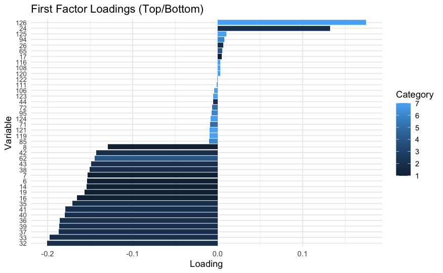

```r
library(ggplot2)
library(reshape2)
library(dplyr)
library(zoo)

enhanced_factor_analysis <- function(data_imputed, results,
                                     n_factors = 4,
                                     variable_labels = NULL,
                                     top_n_loadings = 20,
                                     cluster_vars = TRUE,
                                     heatmap_nvars = NULL,
                                     date_breaks = "5 years",
                                     date_format = "%Y") {
  # 1. Basic Setup: Scale the imputed data
  X <- scale(data_imputed$data)

  # Create a date sequence for the full sample
  dates <- seq.Date(from = as.Date("2001-01-01"),
                    to = as.Date("2019-12-01"),
                    by = "month")

  # 2. Extract factor scores and loadings.
  # If the provided results don't include n_factors, force extraction via PCA.
  if (is.null(results$scores) || ncol(results$scores) < n_factors) {
    warning("Requested n_factors (", n_factors,
            ") exceeds the number of factor scores available (",
            ifelse(is.null(results$scores), 0, ncol(results$scores)),
            "). Forcing extraction via prcomp().")
    pca_res <- prcomp(X, center = FALSE, scale. = FALSE)
    if (ncol(pca_res$x) < n_factors) {
      stop("PCA did not produce enough factors.")
    }
    scores <- pca_res$x[, 1:n_factors, drop = FALSE]
    loadings <- pca_res$rotation[, 1:n_factors, drop = FALSE]
    # Update the results object with the forced extraction
    results$scores <- scores
    results$loadings <- loadings
  } else {
    scores <- results$scores[, 1:n_factors, drop = FALSE]
    loadings <- results$loadings[, 1:n_factors, drop = FALSE]
  }

  # 3. Dimension check: Ensure X and scores have matching rows
  if (nrow(X) != nrow(scores)) {
    stop("Mismatch: X has ", nrow(X), " rows but factor scores have ",
         nrow(scores), " rows.")
  }

  # 4. Compute factor-variable correlations and R²
  factor_correlations <- cor(X, scores, use = "pairwise.complete.obs")
  R2 <- factor_correlations^2

  # 5. Prepare loadings data
  n_vars <- nrow(loadings)
  var_names <- if (is.null(rownames(loadings)) || length(rownames(loadings)) == 0) {
    paste0("Var", seq_len(n_vars))
  } else {
    rownames(loadings)
  }

  # Apply variable labels if provided
  if (!is.null(variable_labels)) {
    var_names <- ifelse(var_names %in% names(variable_labels),
                        variable_labels[var_names],
                        var_names)
  }

  # 6. Get categories from data_imputed attributes (if available)
  categories <- attr(data_imputed$X, "group")
  if (is.null(categories)) {
    categories <- rep("None", n_vars)
  } else {
    categories <- categories[1:n_vars]
  }

  # 7. Create loadings dataframe for the first factor
  loadings_df <- data.frame(
    Variable = var_names,
    Category = categories,
    Loading = loadings[, 1],
    abs_loading = abs(loadings[, 1])
  )

  # Sort by absolute loading descending, then subset to top and bottom loadings if needed
  loadings_df <- loadings_df %>% arrange(desc(abs_loading))
  if (nrow(loadings_df) > 2 * top_n_loadings) {
    top_rows <- head(loadings_df, top_n_loadings)
    bottom_rows <- tail(loadings_df, top_n_loadings)
    loadings_df <- rbind(top_rows, bottom_rows)
  }
  loadings_df <- loadings_df %>% arrange(desc(Loading))

  # Create the loadings bar plot (flip coordinates for readability)
  loading_plot <- ggplot(loadings_df, aes(x = reorder(Variable, Loading),
                                           y = Loading, fill = Category)) +
    geom_bar(stat = "identity") +
    coord_flip() +
    theme_minimal() +
    labs(title = "First Factor Loadings (Top/Bottom)",
         x = "Variable", y = "Loading") +
    theme(axis.text.y = element_text(size = 8))

  # 8. Create factor-variable correlation heatmap
  correlation_data <- melt(factor_correlations)
  colnames(correlation_data) <- c("Variable", "Factor", "value")

  # Optionally subset the heatmap
  if (!is.null(heatmap_nvars) && heatmap_nvars < n_vars) {
    row_sds <- apply(factor_correlations, 1, sd)
    top_var_indices <- order(row_sds, decreasing = TRUE)[1:heatmap_nvars]
    keep_vars <- rownames(factor_correlations)[top_var_indices]
    correlation_data <- correlation_data %>% filter(Variable %in% keep_vars)
  }

  # Cluster variables if requested
  if (cluster_vars) {
    wide_cor <- acast(correlation_data, Variable ~ Factor, value.var = "value")
    dist_matrix <- dist(wide_cor)
    hc <- hclust(dist_matrix)
    var_order <- hc$labels[hc$order]
    correlation_data$Variable <- factor(correlation_data$Variable, levels = var_order)
  } else {
    correlation_data$Variable <- factor(correlation_data$Variable,
                                        levels = unique(correlation_data$Variable))
  }

  correlation_data$Factor <- factor(correlation_data$Factor,
                                    levels = sort(unique(correlation_data$Factor)))

  correlation_plot <- ggplot(correlation_data, aes(x = Factor, y = Variable, fill = value)) +
    geom_tile() +
    scale_fill_gradient2(low = "blue", mid = "white", high = "red",
                         midpoint = 0, limits = c(-1, 1)) +
    theme_minimal() +
    labs(title = "Factor-Variable Correlations",
         x = "Factor", y = "Variable") +
    theme(axis.text.y = element_text(size = 7))

  # 9. Create factor score time series plot with recession shading
  scores_df <- data.frame(Date = dates, scores)
  colnames(scores_df)[-1] <- paste0("Factor", seq_len(n_factors))
  scores_long <- melt(scores_df, id.vars = "Date")
  scores_long <- subset(scores_long, is.finite(value) & !is.na(value))

  # Define example recession periods (adjust as needed)
  recession_dates <- data.frame(
    start = as.Date(c("2001-03-01", "2007-12-01")),
    end   = as.Date(c("2001-11-01", "2009-06-01"))
  )

  time_series_plot <- ggplot(scores_long, aes(x = Date, y = value, color = variable)) +
    geom_rect(data = recession_dates,
              aes(xmin = start, xmax = end, ymin = -Inf, ymax = Inf),
              fill = "grey70", alpha = 0.3, inherit.aes = FALSE) +
    geom_line(na.rm = TRUE) +
    facet_wrap(~ variable, scales = "free_y") +
    theme_minimal() +
    labs(title = "Factor Scores with Recession Periods",
         x = "Date", y = "Standardized Score", color = "Factor") +
    scale_x_date(date_breaks = date_breaks, date_labels = date_format)

  # 10. Compute marginal R² for each factor (average R² across variables)
  marginal_R2 <- colMeans(R2)

  return(list(
    factor_correlations = factor_correlations,
    R2 = R2,
    marginal_R2 = marginal_R2,
    plots = list(
      loadings = loading_plot,
      heatmap = correlation_plot,
      time_series = time_series_plot
    )
  ))
}

# Run the enhanced analysis (this will force extraction of 4 factors using PCA if necessary)
enhanced_results <- enhanced_factor_analysis(data_imputed = data_imputed, results = results, n_factors = 4)
# Display plots individually
print(enhanced_results$plots$loadings)
```

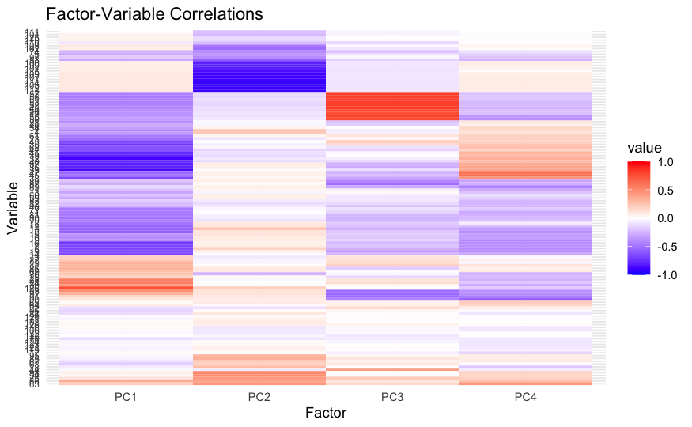

```r
print(enhanced_results$plots$heatmap)
```

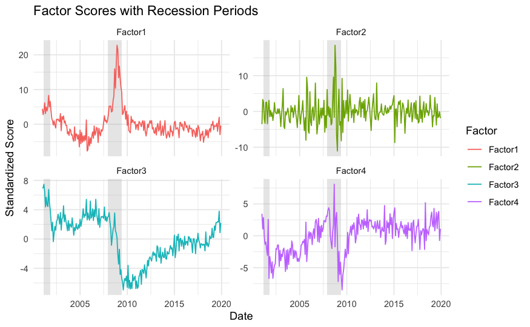

```r
print(enhanced_results$plots$time_series)
```

```r
# Print marginal R² values
cat("\nMarginal R² for each factor:\n")
```

```
Marginal R² for each factor:
```

```r
print(round(enhanced_results$marginal_R2, 4))
```

```
   PC1    PC2    PC3    PC4
0.1490 0.0961 0.0812 0.0571
```

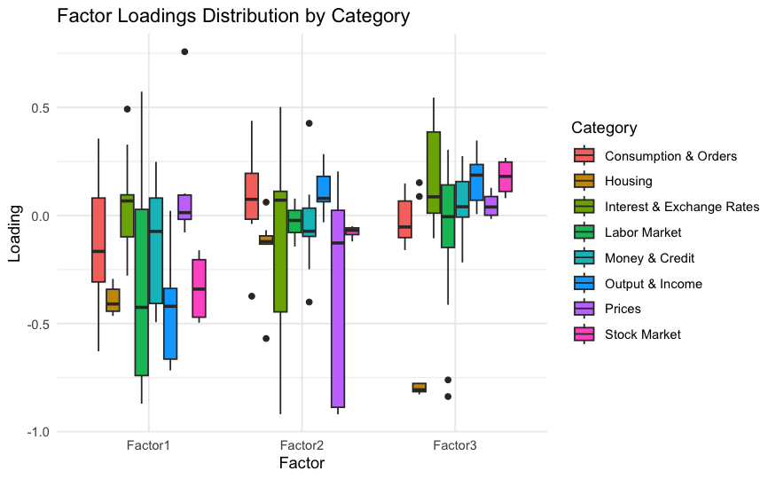

```r
library(ggplot2)
library(reshape2)
library(dplyr)
library(zoo)
library(fbi)  # fbi package for describe_md()

enhanced_factor_analysis <- function(data_imputed, results, n_factors = 3) {
  # 1. Basic Setup
  X <- scale(data_imputed[["X"]])
  dates <- seq.Date(from = as.Date("2001-01-01"),
                    to = as.Date("2019-12-01"),
                    by = "month")

  # 2. Extract factors and loadings
  scores <- results$scores[, 1:n_factors, drop = FALSE]
  loadings <- results$loadings[, 1:n_factors, drop = FALSE]

  # 3. Get FRED‑MD variable names and descriptions.
  var_names <- colnames(data_imputed[["X"]])
  if(is.null(var_names) || all(var_names == "")) {
    stop("Column names for data_imputed[['X']] are not set. Please assign the official FRED-MD mnemonics as column names.")
  }

  var_descriptions <- sapply(var_names, function(x) {
    desc <- try(describe_md(x, name.only = FALSE), silent = TRUE)
    if(inherits(desc, "try-error") || is.null(desc$description)) {
      return(x)  # fallback: use the mnemonic
    } else {
      return(desc$description[1])
    }
  })

  # 4. Get and map categories using the official FRED‑MD grouping
  fred_categories <- c(
    "1" = "Output & Income",
    "2" = "Labor Market",
    "3" = "Housing",
    "4" = "Consumption & Orders",
    "5" = "Money & Credit",
    "6" = "Interest & Exchange Rates",
    "7" = "Prices",
    "8" = "Stock Market"
  )
  categories <- attr(data_imputed[["X"]], "group")
  if(is.null(categories) || length(categories) == 0) {
    categories <- rep("None", nrow(loadings))
  } else {
    categories <- fred_categories[as.character(categories)]
    categories[is.na(categories)] <- "None"
    if(length(categories) != nrow(loadings)) {
      categories <- rep("None", nrow(loadings))
    }
  }

  # Assign the official variable names as rownames for loadings.
  rownames(loadings) <- var_names

  # 5. Economic Interpretation Function
  factor_interpretation <- function(loadings, categories, threshold = 0.3, var_descriptions) {
    interpretations <- list()
    var_names_local <- rownames(loadings)
    for(i in 1:ncol(loadings)) {
      sorted_loadings <- sort(loadings[, i], decreasing = TRUE)
      top_pos <- sorted_loadings[sorted_loadings > threshold]
      top_neg <- sorted_loadings[sorted_loadings < -threshold]

      pos_names <- if(length(names(top_pos)) == 0) {
        var_names_local[which(loadings[, i] > threshold)]
      } else {
        names(top_pos)
      }
      neg_names <- if(length(names(top_neg)) == 0) {
        var_names_local[which(loadings[, i] < -threshold)]
      } else {
        names(top_neg)
      }

      pos_cats <- table(categories[match(pos_names, var_names_local)])
      neg_cats <- table(categories[match(neg_names, var_names_local)])

      pos_vars <- data.frame(
        variable = pos_names,
        description = var_descriptions[match(pos_names, var_names_local)],
        loading = as.numeric(top_pos[match(pos_names, names(top_pos))]),
        category = categories[match(pos_names, var_names_local)]
      )

      neg_vars <- data.frame(
        variable = neg_names,
        description = var_descriptions[match(neg_names, var_names_local)],
        loading = as.numeric(top_neg[match(neg_names, names(top_neg))]),
        category = categories[match(neg_names, var_names_local)]
      )

      interpretations[[i]] <- list(
        positive = list(
          variables = pos_vars,
          category_summary = pos_cats
        ),
        negative = list(
          variables = neg_vars,
          category_summary = neg_cats
        )
      )
    }
    return(interpretations)
  }

  interpretations <- factor_interpretation(loadings, categories, threshold = 0.3, var_descriptions = var_descriptions)

  # 6. Factor Stability Analysis Function
  stability_analysis <- function(scores, window = 24) {
    n_fac <- ncol(scores)
    roll_cors <- matrix(NA, nrow = nrow(scores) - window + 1,
                        ncol = (n_fac * (n_fac - 1)) / 2)
    colnames(roll_cors) <- paste0("F", rep(1:(n_fac - 1)),
                                  "_F", unlist(lapply(2:n_fac, function(x) x:n_fac)))
    for(i in window:nrow(scores)) {
      window_data <- scores[(i - window + 1):i, ]
      cors <- cor(window_data)[lower.tri(cor(window_data))]
      roll_cors[i - window + 1, ] <- cors
    }
    return(roll_cors)
  }

  stability_results <- stability_analysis(scores)

  # 7. Create Enhanced Visualizations
  ## 7.1 Factor Loadings by Category (Boxplot)
  loadings_df <- data.frame(
    Variable = var_names,
    Category = categories,
    as.data.frame(loadings)
  )
  names(loadings_df)[3:(2 + n_factors)] <- paste0("Factor", 1:n_factors)

  loadings_long <- melt(loadings_df,
                        id.vars = c("Variable", "Category"),
                        variable.name = "Factor",
                        value.name = "Loading")

  category_plot <- ggplot(loadings_long, aes(x = Factor, y = Loading, fill = Category)) +
    geom_boxplot() +
    theme_minimal() +
    labs(title = "Factor Loadings Distribution by Category")

  ## 7.2 Factor Stability Plot
  stability_df <- data.frame(
    Date = dates[24:length(dates)],
    stability_results
  )
  stability_plot <- ggplot(melt(stability_df, id.vars = "Date"),
                           aes(x = Date, y = value, color = variable)) +
    geom_line() +
    theme_minimal() +
    labs(title = "Rolling Factor Correlations",
         y = "Correlation",
         color = "Factor Pair")

  ## 7.3 Factor Scores with Recession Shading
  scores_df <- data.frame(
    Date = dates[1:nrow(scores)],
    as.data.frame(scores)
  )
  names(scores_df)[-1] <- paste0("Factor", 1:n_factors)

  scores_long <- melt(scores_df, id.vars = "Date")

  recession_dates <- data.frame(
    start = as.Date(c("2001-03-01", "2007-12-01")),
    end = as.Date(c("2001-11-01", "2009-06-01"))
  )

  scores_plot <- ggplot(scores_long, aes(x = Date, y = value)) +
    geom_line(aes(color = variable)) +
    facet_wrap(~ variable, scales = "free_y") +
    theme_minimal() +
    labs(title = "Factor Scores Time Series with Recession Periods",
         color = "Factor") +
    geom_rect(data = recession_dates,
              aes(xmin = start, xmax = end, ymin = -Inf, ymax = Inf),
              fill = "grey70", alpha = 0.3, inherit.aes = FALSE) +
    scale_x_date(date_breaks = "5 years", date_labels = "%Y")

  # 8. Prepare Factors for Forecasting
  # Use the official FRED-MD data for target variable extraction.
  if("INDPRO" %in% colnames(data_imputed[["X"]])) {
    target_variable <- data_imputed[["X"]][, "INDPRO"]
  } else {
    warning("Column 'INDPRO' not found; using first column as target variable.")
    target_variable <- data_imputed[["X"]][, 1]
  }
  forecasting_data <- data.frame(
    date = dates[1:nrow(scores)],
    as.data.frame(scores),
    target_variable = target_variable[1:nrow(scores)]
  )

  # 9. Compute Factor-Variable Correlations and Marginal R²
  factor_correlations <- cor(X, scores, use = "pairwise.complete.obs")
  R2 <- factor_correlations^2
  marginal_R2 <- colMeans(R2)

  return(list(
    interpretations = interpretations,
    stability = stability_results,
    forecasting_data = forecasting_data,
    plots = list(
      category_plot = category_plot,
      stability_plot = stability_plot,
      scores_plot = scores_plot
    ),
    marginal_R2 = marginal_R2,
    categories = categories,
    var_descriptions = var_descriptions
  ))
}

# Run enhanced analysis
enhanced_results <- enhanced_factor_analysis(data_imputed, results, n_factors = 3)

# Display plots
print(enhanced_results$plots$category_plot)
```

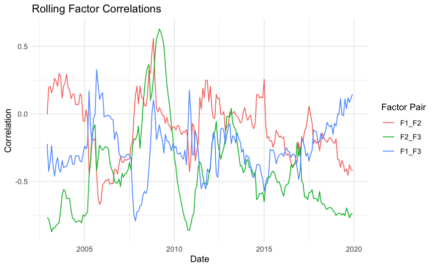

```r
print(enhanced_results$plots$stability_plot)
```

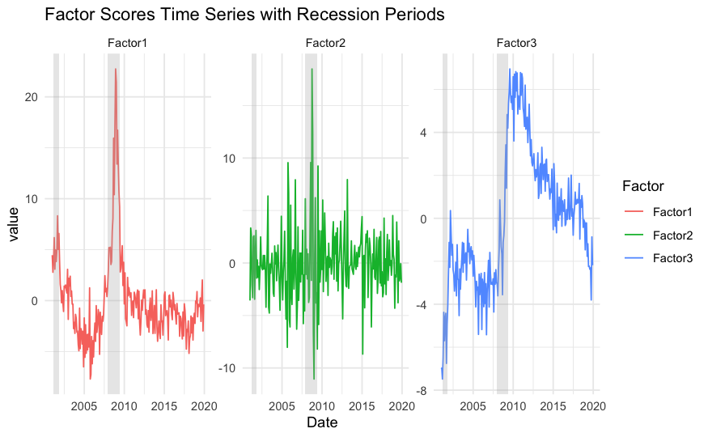

```r
print(enhanced_results$plots$scores_plot)
```

```r
# Print detailed economic interpretations
cat("\nDetailed Economic Interpretation of Factors:\n")
```

```
Detailed Economic Interpretation of Factors:
```

```r
for(i in 1:length(enhanced_results$interpretations)) {
  cat(sprintf("\nFactor %d:\n", i))
  cat("\nTop 10 Positive Loading Variables:\n")
  print(head(enhanced_results$interpretations[[i]]$positive$variables, 10))
  cat("\nPositive Loading Category Summary:\n")
  print(enhanced_results$interpretations[[i]]$positive$category_summary)
  cat("\nTop 10 Negative Loading Variables:\n")
  print(head(enhanced_results$interpretations[[i]]$negative$variables, 10))
  cat("\nNegative Loading Category Summary:\n")
  print(enhanced_results$interpretations[[i]]$negative$category_summary)
}
```

```
Factor 1:

Top 10 Positive Loading Variables:
```

|  | variable | description | loading | category |
| --- | --- | --- | --- | --- |
| VIXCLSx | VIXCLSx | Real Personal Income | 0.7573653 | Prices |
| UNRATE | UNRATE | Civilian Unemployment Rate | 0.5727197 | Labor Market |
| UEMP15OV | UEMP15OV | Civilians Unemployed - 15 Weeks & Over | 0.5466684 | Labor Market |
| BAAFFM | BAAFFM | Moody s Baa Corporate Bond Minus FEDFUNDS | 0.4918710 | Interest & Exchange Rates |
| UEMP27OV | UEMP27OV | Civilians Unemployed for 27 Weeks and Over | 0.4468919 | Labor Market |
| M2REAL | M2REAL | Real M2 Money Stock | 0.3557935 | Consumption & Orders |
| AAAFFM | AAAFFM | Moody s Aaa Corporate Bond Minus FEDFUNDS | 0.3278291 | Interest & Exchange Rates |
| CLAIMSx | CLAIMSx | Initial Claims | 0.3240696 | Labor Market |
| COMPAPFFx | COMPAPFFx | 3-Month Commercial Paper Minus FEDFUNDS | 0.3202656 | Interest & Exchange Rates |
| UEMP15T26 | UEMP15T26 | Civilians Unemployed for 15-26 Weeks | 0.3177126 | Labor Market |

```
Positive Loading Category Summary:

     Consumption & Orders Interest & Exchange Rates              Labor Market
                        1                         3                         5
                   Prices
                        1

Top 10 Negative Loading Variables:
```

|  | variable | description | loading | category |
| --- | --- | --- | --- | --- |
| DPCERA3M086SBEA | DPCERA3M086SBEA | Real personal consumption expenditures | -0.3032465 | Consumption & Orders |
| RETAILx | RETAILx | Retail and Food Services Sales | -0.3073259 | Consumption & Orders |
| CES1021000001 | CES1021000001 | All Employees: Mining and Logging: Mining | -0.3316298 | Labor Market |
| HOUSTMW | HOUSTMW | Housing Starts, Midwest | -0.3362022 | Housing |
| RPI | RPI | Real Personal Income | -0.3373863 | Output & Income |
| PERMITMW | PERMITMW | New Private Housing Permits, Midwest (SAAR) | -0.3565231 | Housing |
| IPNMAT | IPNMAT | IP: Nondurable Materials | -0.3587376 | Output & Income |
| HOUSTNE | HOUSTNE | Housing Starts, Northeast | -0.3750815 | Labor Market |
| HWIURATIO | HWIURATIO | Ratio of Help Wanted/No. Unemployed | -0.3912358 | Labor Market |
| IPCONGD | IPCONGD | IP: Consumer Goods | -0.3922302 | Output & Income |

```
Negative Loading Category Summary:

Consumption & Orders              Housing         Labor Market
                   5                    8                   18
      Money & Credit      Output & Income         Stock Market
                   3                   13                    2

Factor 2:

Top 10 Positive Loading Variables:
```

|  | variable | description | loading | category |
| --- | --- | --- | --- | --- |
| EXCAUSx | EXCAUSx | Canada / U.S. Foreign Exchange Rate | 0.5016778 | Interest & Exchange Rates |
| TWEXAFEGSMTHx | TWEXAFEGSMTHx | Real Personal Income | 0.4834552 | Interest & Exchange Rates |
| ISRATIOx | ISRATIOx | Total Business: Inventories to Sales Ratio | 0.4376639 | Consumption & Orders |
| S.P.div.yield | S.P.div.yield | Real Personal Income | 0.4262403 | Money & Credit |
| M2REAL | M2REAL | Real M2 Money Stock | 0.3898710 | Consumption & Orders |
| BAA | BAA | Moody s Seasoned Baa Corporate Bond Yield | 0.3377927 | Interest & Exchange Rates |
| EXSZUSx | EXSZUSx | Switzerland / U.S. Foreign Exchange Rate | 0.3226190 | Interest & Exchange Rates |

```
Positive Loading Category Summary:

     Consumption & Orders Interest & Exchange Rates            Money & Credit
                        2                         4                         1

Top 10 Negative Loading Variables:
```

|  | variable | description | loading | category |
| --- | --- | --- | --- | --- |
| RETAILx | RETAILx | Retail and Food Services Sales | -0.3733521 | Consumption & Orders |
| S.P.500 | S.P.500 | Real Personal Income | -0.4003082 | Money & Credit |
| EXUSUKx | EXUSUKx | U.S. / U.K. Foreign Exchange Rate | -0.4012199 | Interest & Exchange Rates |
| OILPRICEx | OILPRICEx | Crude Oil, spliced WTI and Cushing | -0.4608639 | Interest & Exchange Rates |
| WPSID62 | WPSID62 | PPI: Crude Materials | -0.5224836 | Interest & Exchange Rates |
| ACOGNO | ACOGNO | New Orders for Consumer Goods | -0.5688235 | Housing |
| WPSFD49207 | WPSFD49207 | PPI: Finished Goods | -0.8013203 | Interest & Exchange Rates |
| WPSFD49502 | WPSFD49502 | PPI: Finished Consumer Goods | -0.8069684 | Interest & Exchange Rates |
| WPSID61 | WPSID61 | PPI: Intermediate Materials | -0.8089407 | Interest & Exchange Rates |
| PCEPI | PCEPI | Personal Cons. Expend.: Chain Index | -0.8556212 | Prices |

```
Negative Loading Category Summary:

     Consumption & Orders                   Housing Interest & Exchange Rates
                        1                         1                         7
           Money & Credit                    Prices
                        1                         7

Factor 3:

Top 10 Positive Loading Variables:
```

|  | variable | description | loading | category |
| --- | --- | --- | --- | --- |
| T10YFFM | T10YFFM | 10-Year Treasury C Minus FEDFUNDS | 0.5451285 | Interest & Exchange Rates |
| AAAFFM | AAAFFM | Moody s Aaa Corporate Bond Minus FEDFUNDS | 0.5344755 | Interest & Exchange Rates |
| BAAFFM | BAAFFM | Moody s Baa Corporate Bond Minus FEDFUNDS | 0.5170930 | Interest & Exchange Rates |
| TB3SMFFM | TB3SMFFM | 3-Month Treasury C Minus FEDFUNDS | 0.5089356 | Interest & Exchange Rates |
| T5YFFM | T5YFFM | 5-Year Treasury C Minus FEDFUNDS | 0.4335433 | Interest & Exchange Rates |
| TB6SMFFM | TB6SMFFM | 6-Month Treasury C Minus FEDFUNDS | 0.4164676 | Interest & Exchange Rates |
| CUMFNS | CUMFNS | Capacity Utilization: Manufacturing | 0.3467328 | Output & Income |
| NDMANEMP | NDMANEMP | All Employees: Nondurable goods | 0.3038221 | Labor Market |

```
Positive Loading Category Summary:

Interest & Exchange Rates              Labor Market           Output & Income
                        6                         1                         1

Top 10 Negative Loading Variables:
```

|  | variable | description | loading | category |
| --- | --- | --- | --- | --- |
| USGOVT | USGOVT | All Employees: Government | -0.4130682 | Labor Market |
| HOUSTNE | HOUSTNE | Housing Starts, Northeast | -0.7604688 | Labor Market |
| HOUSTMW | HOUSTMW | Housing Starts, Midwest | -0.7756164 | Housing |
| PERMITNE | PERMITNE | New Private Housing Permits, Northeast (SAAR) | -0.7803320 | Housing |
| PERMITMW | PERMITMW | New Private Housing Permits, Midwest (SAAR) | -0.7993893 | Housing |
| HOUSTW | HOUSTW | Housing Starts, West | -0.8124118 | Housing |
| PERMITW | PERMITW | New Private Housing Permits, West (SAAR) | -0.8131721 | Housing |
| PERMITS | PERMITS | New Private Housing Permits, South (SAAR) | -0.8154835 | Housing |
| PERMIT | PERMIT | New Private Housing Permits (SAAR) | -0.8261385 | Housing |
| HOUSTS | HOUSTS | Housing Starts, South | -0.8274989 | Housing |

```
Negative Loading Category Summary:

     Housing Labor Market
           8            3
```

```r
# Print stability summary with interpretation
cat("\nFactor Stability Analysis:\n")
```

```
Factor Stability Analysis:
```

```r
stability_summary <- summary(enhanced_results$stability)
print(stability_summary)
```

```
     F1_F2              F2_F3             F1_F3
 Min.   :-0.67177   Min.   :-0.8733   Min.   :-0.7939
 1st Qu.:-0.24666   1st Qu.:-0.6674   1st Qu.:-0.3650
 Median :-0.08980   Median :-0.4761   Median :-0.2792
 Mean   :-0.10143   Mean   :-0.4212   Mean   :-0.2525
 3rd Qu.: 0.06527   3rd Qu.:-0.2552   3rd Qu.:-0.1400
 Max.   : 0.55983   Max.   : 0.6295   Max.   : 0.3288
```

```r
cat("\nStability Interpretation:\n")
```

```
Stability Interpretation:
```

```r
cat("- Factor correlations range from", round(min(enhanced_results$stability, na.rm = TRUE), 3),
    "to", round(max(enhanced_results$stability, na.rm = TRUE), 3), "\n")
```

```
- Factor correlations range from -0.873 to 0.629
```

```r
cat("- Median correlations suggest",
    ifelse(median(abs(enhanced_results$stability), na.rm = TRUE) < 0.3,
           "relatively stable and distinct factors",
           "some factor interdependence"),
    "\n")
```

```
- Median correlations suggest relatively stable and distinct factors
```

Factor 1: “Financial Stress and Labor Market Conditions”

Positive loadings: Strong on unemployment measures (UNRATE, UEMP15OV) Financial spreads (BAAFFM, AAAFFM) Market volatility (VIXCLSx) Negative loadings: Real activity (RPI, IPCONGD) Housing (HOUSTMW, HOUSTNE) Retail sales (RETAILx) This suggests Factor 1 captures economic distress, rising during periods of high unemployment and financial market stress. Factor 2: “Price Pressures and Exchange Rates”

Positive loadings: Exchange rates (EXCAUSx, TWEXAFEGSMTHx) Inventory ratios (ISRATIOx) Corporate bonds (BAA) Negative loadings: Price indices (WPSFD49207, WPSFD49502, PCEPI) Oil prices (OILPRICEx) This factor appears to capture price pressures and international financial conditions. Factor 3: “Interest Rate Spreads and Housing”

Positive loadings: Interest rate spreads (T10YFFM, AAAFFM, BAAFFM) Manufacturing (CUMFNS) Negative loadings: Housing sector (PERMIT, HOUSTS, HOUSTW) This factor seems to capture monetary conditions and their impact on housing. Quality Assessment:

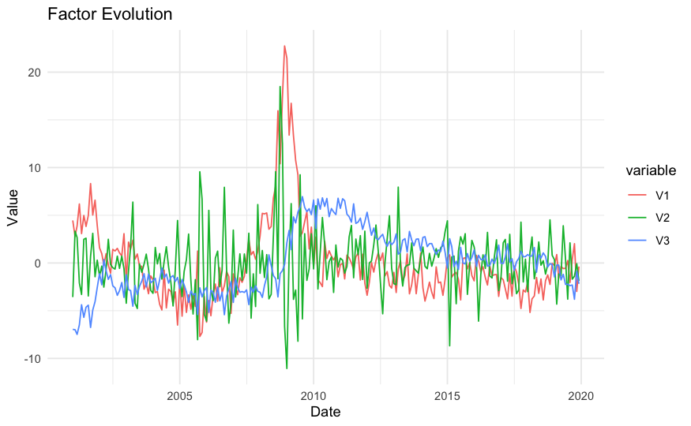

```r
# Load required libraries
library(vars)
library(forecast)
library(ggplot2)
library(reshape2)

# Define create_lags in the global environment
create_lags <- function(x, max_lag) {
  n <- length(x)
  lagged <- matrix(NA, n, max_lag)
  colnames(lagged) <- paste0("L", 1:max_lag)
  for(i in 1:max_lag) {
    lagged[-(1:i), i] <- x[1:(n-i)]
  }
  return(lagged)
}

# FAR forecasting framework
far_framework <- function(data_imputed, enhanced_results, h_max = 12) {
  # Get target variable (INDPRO) and factors
  y <- data_imputed[["X"]][, "INDPRO"]
  factors <- enhanced_results$forecasting_data[, paste0("V", 1:3)]
  dates <- enhanced_results$forecasting_data$date

  # Create forecasting data structure
  T <- length(y)
  p <- 4  # Number of autoregressive lags
  q <- 2  # Number of factor lags

  # Direct h-step ahead model
  far_direct <- function(y, factors, h, p, q) {
    # Create lags using the global create_lags function
    y_lags <- create_lags(y, p)
    factor_lags <- lapply(1:ncol(factors), function(i) {
      create_lags(factors[, i], q)
    })

    # Combine predictors
    X <- do.call(cbind, c(
      list(y_lags),
      factor_lags
    ))

    # Create h-step ahead target
    y_target <- y[(p+h):(T)]
    X <- X[1:(T - p - h + 1), ]

    # Remove NA rows and align indices
    valid_idx <- complete.cases(y_target, X)
    y_target <- y_target[valid_idx]
    X <- X[valid_idx, ]

    # Store indices for later reference
    idx <- which(valid_idx) + (p + h - 1)

    # Estimate model
    model <- lm(y_target ~ X)

    return(list(
      model = model,
      X = X,
      y = y_target,
      dates = dates[idx],  # Store corresponding dates
      indices = idx        # Store indices for alignment
    ))
  }

  # Estimate models for horizons 1 to h_max
  models <- lapply(1:h_max, function(h) {
    far_direct(y, factors, h, p, q)
  })

  # In-sample fit analysis
  insample_fit <- lapply(models, function(m) {
    fitted_vals <- fitted(m$model)
    resid <- residuals(m$model)
    r2 <- summary(m$model)$r.squared
    rmse <- sqrt(mean(resid^2))
    list(
      fitted = fitted_vals,
      residuals = resid,
      R2 = r2,
      RMSE = rmse,
      dates = m$dates  # Store dates for plotting
    )
  })

  # Diagnostic plots for first horizon
  h1_data <- data.frame(
    date = models[[1]]$dates,
    actual = models[[1]]$y,
    fitted = fitted(models[[1]]$model)
  )

  diagnostic_plots <- list(
    # Factor loadings over time
    loadings_plot = ggplot(
      data = melt(
        data.frame(date = dates, factors),
        id.vars = "date"   # Specify 'date' as the id variable
      ),
      aes(x = date, y = value, color = variable)
    ) +
      geom_line() +
      theme_minimal() +
      labs(title = "Factor Evolution", x = "Date", y = "Value"),

    # Actual vs Fitted (h=1)
    fit_plot = ggplot(h1_data, aes(x = date)) +
      geom_line(aes(y = actual, color = "Actual")) +
      geom_line(aes(y = fitted, color = "Fitted")) +
      theme_minimal() +
      labs(title = "Actual vs Fitted (h=1)", x = "Date", y = "INDPRO") +
      scale_color_manual(values = c("Actual" = "black", "Fitted" = "red"))
  )

  # Add forecast evaluation metrics
  eval_metrics <- lapply(1:h_max, function(h) {
    model <- models[[h]]
    fitted_vals <- fitted(model$model)
    actual <- model$y

    # Compute metrics
    mse <- mean((actual - fitted_vals)^2)
    rmse <- sqrt(mse)
    mae <- mean(abs(actual - fitted_vals))

    data.frame(
      horizon = h,
      RMSE = rmse,
      MAE = mae,
      R2 = summary(model$model)$r.squared
    )
  })
  eval_metrics <- do.call(rbind, eval_metrics)

  return(list(
    models = models,
    insample_fit = insample_fit,
    diagnostics = diagnostic_plots,
    evaluation = eval_metrics,
    data = list(
      y = y,
      factors = factors,
      dates = dates
    )
  ))
}

# Run the FAR framework
far_results <- far_framework(data_imputed, enhanced_results)

# Display diagnostic plots
print(far_results$diagnostics$loadings_plot)
```

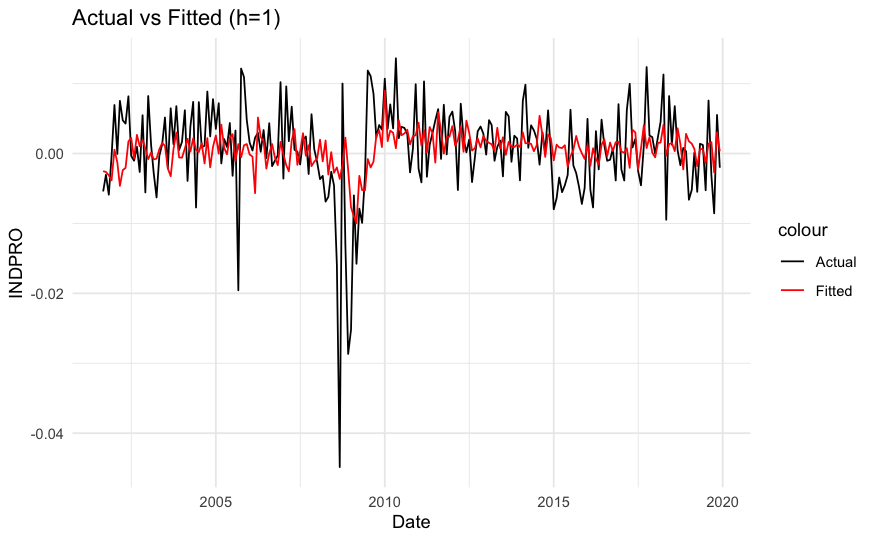

```r
print(far_results$diagnostics$fit_plot)
```

```r
# Print evaluation metrics
cat("\nForecast Evaluation Metrics:\n")
```

```
Forecast Evaluation Metrics:
```

```r
print(far_results$evaluation)
```

| horizon | RMSE | MAE | R2 |
| --- | --- | --- | --- |
| 1 | 0.006285431 | 0.004398105 | 0.12630271 |
| 2 | 0.006376445 | 0.004328827 | 0.10160401 |
| 3 | 0.006585145 | 0.004508622 | 0.04489444 |
| 4 | 0.006576594 | 0.004521084 | 0.04760502 |
| 5 | 0.006471693 | 0.004540655 | 0.08188773 |
| 6 | 0.006549801 | 0.004611221 | 0.06020433 |
| 7 | 0.006619832 | 0.004519792 | 0.04441424 |
| 8 | 0.006598996 | 0.004532532 | 0.05027092 |
| 9 | 0.006524337 | 0.004531801 | 0.07438356 |
| 10 | 0.006608828 | 0.004537405 | 0.05342154 |

[output cut: 2 more lines]

```r
# Print detailed statistics for h=1
cat("\nDetailed h=1 Model Summary:\n")
```

```
Detailed h=1 Model Summary:
```